[figure not shown]

# WELCOME!

Welcome to "*Clustering (Customer Segmentation) Project*". This is the last medium project of *Machine Learning* course.

At the end of this project, you will have performed *Cluster Analysis* with an *Unsupervised Learning* method.

In this project, customers are required to be segmented according to the purchasing history obtained from the membership cards of a big mall.

This project is less challenging than other projects. After getting to know the data set quickly, you are expected to perform *Exploratory Data Analysis*. You should observe the distribution of customers according to different variables, also discover relationships and correlations between variables. Then you will spesify the different variables to use for cluster analysis.

The last step in customer segmentation is to group the customers into distinct clusters based on their characteristics and behaviors. One of the most common methods for clustering is *K-Means Clustering*, which partitions the data into k clusters based on the distance to the cluster centroids. Other clustering methods include *hierarchical clustering*, density-based clustering, and spectral clustering. Each cluster can be assigned a label that describes its main features and preferences.

- *NOTE:* *This project assumes that you already know the basics of coding in Python. You should also be familiar with the theory behind Cluster Analysis and scikit-learn module as well as Machine Learning before you begin.*

# #Tasks

#### 1. Import Libraries, Load Dataset, Exploring Data

- Import Libraries
- Load Dataset
- Explore Data

#### 2. Exploratory Data Analysis (EDA)

#### 3. Cluster Analysis

- Clustering based on Age and Spending Score

  *i. Create a new dataset with two variables of your choice*

  *ii. Determine optimal number of clusters*

  *iii. Apply K Means*

  *iv. Visualizing and Labeling All the Clusters*
- Clustering based on Annual Income and Spending Score

  *i. Create a new dataset with two variables of your choice*

  *ii. Determine optimal number of clusters*

  *iii. Apply K Means*

  *iv. Visualizing and Labeling All the Clusters*
- Hierarchical Clustering

  *i. Determine optimal number of clusters using Dendogram*

  *ii. Apply Agglomerative Clustering*

  *iii. Visualizing and Labeling All the Clusters*
- Conclusion

## 1. Import Libraries, Load Dataset, Exploring Data

There is a big mall in a specific city that keeps information of its customers who subscribe to a membership card. In the membetrship card they provide following information : gender, age and annula income. The customers use this membership card to make all the purchases in the mall, so tha mall has the purchase history of all subscribed members and according to that they compute the spending score of all customers. You have to segment these customers based on the details given.

#### Import Libraries

```python
import pandas as pd
from yellowbrick.cluster import SilhouetteVisualizer
import numpy as np
import matplotlib.pyplot as plt
import seaborn as sns
%matplotlib inline
import warnings
warnings.filterwarnings('ignore')
from sklearn.cluster import KMeans
from sklearn.metrics import silhouette_score
from scipy.cluster.hierarchy import dendrogram, linkage
from sklearn.preprocessing import MinMaxScaler
from sklearn.cluster import AgglomerativeClustering
```

#### Load Dataset

```python
customersData = pd.read_csv('Mall_Customers.csv')
```

#### Explore Data

You can rename columns to more usable, if you need.

```python
customersData.head()
```

|  | CustomerID | Gender | Age | Annual Income (k$) | Spending Score (1-100) |
| --- | --- | --- | --- | --- | --- |
| 0 | 1 | Male | 19 | 15 | 39 |
| 1 | 2 | Male | 21 | 15 | 81 |
| 2 | 3 | Female | 20 | 16 | 6 |
| 3 | 4 | Female | 23 | 16 | 77 |
| 4 | 5 | Female | 31 | 17 | 40 |

```python
customersData.tail()
```

|  | CustomerID | Gender | Age | Annual Income (k$) | Spending Score (1-100) |
| --- | --- | --- | --- | --- | --- |
| 195 | 196 | Female | 35 | 120 | 79 |
| 196 | 197 | Female | 45 | 126 | 28 |
| 197 | 198 | Male | 32 | 126 | 74 |
| 198 | 199 | Male | 32 | 137 | 18 |
| 199 | 200 | Male | 30 | 137 | 83 |

```python
customersData.sample(7)
```

|  | CustomerID | Gender | Age | Annual Income (k$) | Spending Score (1-100) |
| --- | --- | --- | --- | --- | --- |
| 123 | 124 | Male | 39 | 69 | 91 |
| 10 | 11 | Male | 67 | 19 | 14 |
| 68 | 69 | Male | 19 | 48 | 59 |
| 127 | 128 | Male | 40 | 71 | 95 |
| 79 | 80 | Female | 49 | 54 | 42 |
| 192 | 193 | Male | 33 | 113 | 8 |
| 45 | 46 | Female | 24 | 39 | 65 |

## 2. Exploratory Data Analysis (EDA)

After performing Cluster Analysis, you need to know the data well in order to label the observations correctly. Analyze frequency distributions of features, relationships and correlations between the independent variables and the dependent variable. It is recommended to apply data visualization techniques. Observing breakpoints helps you to internalize the data.

```python
customersData.drop(['CustomerID'], axis = 1, inplace = True)
```

```python
customersData.rename(columns = {'Annual Income (k$)':'Annual Income', 'Spending Score (1-100)':'Spending Score'}, inplace = True)
```

```python
customersData.columns
```

```
Index(['Gender', 'Age', 'Annual Income', 'Spending Score'], dtype='object')
```

```python
customersData.shape
```

```
(200, 4)
```

```python
customersData.info
```

```
<bound method DataFrame.info of      Gender  Age  Annual Income  Spending Score
0      Male   19             15              39
1      Male   21             15              81
2    Female   20             16               6
3    Female   23             16              77
4    Female   31             17              40
..      ...  ...            ...             ...
195  Female   35            120              79
196  Female   45            126              28
197    Male   32            126              74
198    Male   32            137              18
199    Male   30            137              83

[200 rows x 4 columns]>
```

```python
customersData.dtypes
```

```
Gender            object
Age                int64
Annual Income      int64
Spending Score     int64
dtype: object
```

```python
customersData.nunique()
```

```
Gender             2
Age               51
Annual Income     64
Spending Score    84
dtype: int64
```

```python
customersData.duplicated().sum()
```

```
0
```

```python
customersData.isnull().sum().sum()
```

```
0
```

```python
customersDataNumdescribe = customersData.describe().T
customersDataNumdescribe
```

|  | count | mean | std | min | 25% | 50% | 75% | max |
| --- | --- | --- | --- | --- | --- | --- | --- | --- |
| Age | 200.0 | 38.85 | 13.969007 | 18.0 | 28.75 | 36.0 | 49.0 | 70.0 |
| Annual Income | 200.0 | 60.56 | 26.264721 | 15.0 | 41.50 | 61.5 | 78.0 | 137.0 |
| Spending Score | 200.0 | 50.20 | 25.823522 | 1.0 | 34.75 | 50.0 | 73.0 | 99.0 |

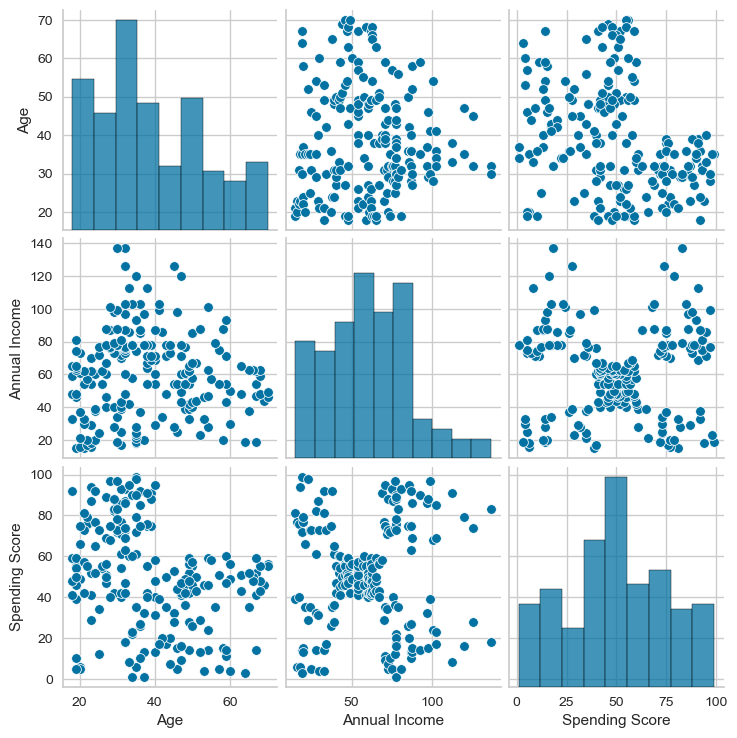

```python
sns.pairplot(customersData)
plt.show()
```

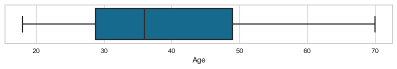

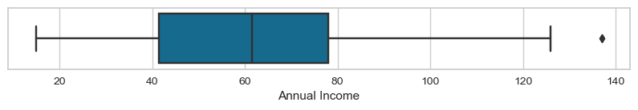

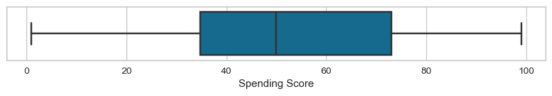

```python
numberRow = customersDataNumdescribe.index.tolist()
for i in range(len (numberRow)):
        plt.figure(figsize=(10,1))
        sns.boxplot(data=customersData, x=numberRow[i])
```

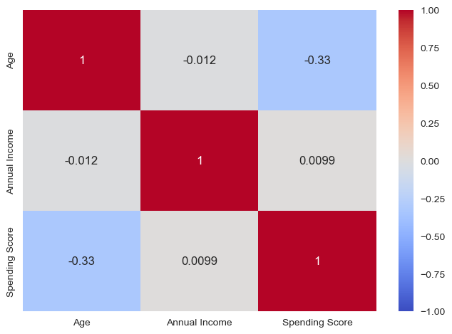

```python
sns.heatmap(customersData.corr(),vmin=-1, vmax=1, annot=True, cmap="coolwarm")
```

```python
for i in range (len(numberRow)) :
        IQR = customersDataNumdescribe['75%'][i] - customersDataNumdescribe['25%'][i]
        lower_bound = customersDataNumdescribe['25%'][i] - 1.5 * IQR
        upper_bound = customersDataNumdescribe['75%'][i] + 1.5 * IQR
        customersData = customersData[((customersData[numberRow[i]] >= lower_bound) &( customersData[numberRow[i]] <= upper_bound))]
```

```python
customersData.shape
```

```
(198, 4)
```

```python
customersData.describe(include=['object'],exclude=['int64']).T
```

|  | count | unique | top | freq |
| --- | --- | --- | --- | --- |
| Gender | 198 | 2 | Female | 112 |

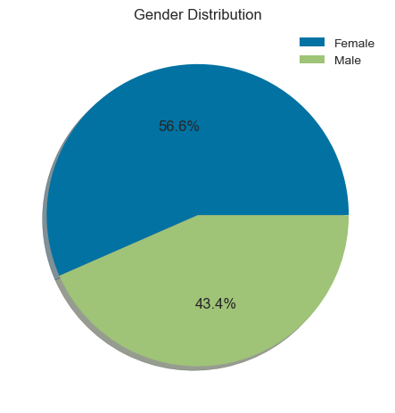

```python
plt.pie(customersData['Gender'].value_counts(),autopct='%1.1f%%', shadow=True)
plt.legend(labels=['Female','Male'])
plt.title('Gender Distribution')
```

```python
customersData['Gender'] = customersData['Gender'].replace(['Female', 'Male'], ['0', '1'])
```

```python
customersData['Gender'].value_counts()
customersData['Gender'] = customersData['Gender'].astype(int)
```

```python
customersData.dtypes
```

```
Gender            int32
Age               int64
Annual Income     int64
Spending Score    int64
dtype: object
```

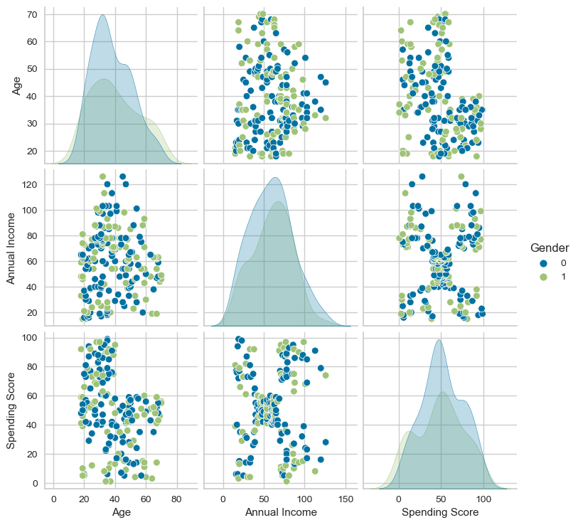

```python
sns.pairplot(customersData, hue='Gender');
```

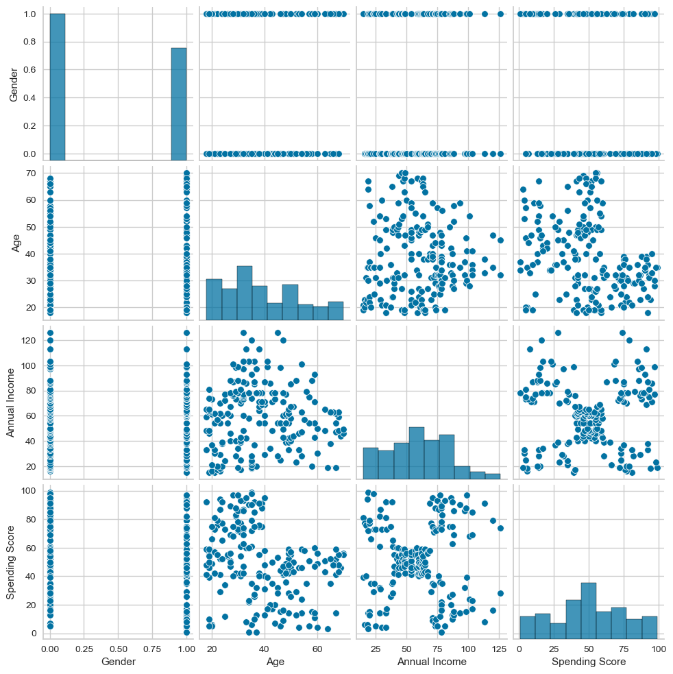

```python
sns.pairplot(customersData);
```

## 3. Cluster Analysis

The purpose of the project is to perform cluster analysis using [K-Means](https://towardsdatascience.com/understanding-k-means-clustering-in-machine-learning-6a6e67336aa1) and [Hierarchical Clustering](https://medium.com/analytics-vidhya/hierarchical-clustering-d2d92835280c) algorithms. Using a maximum of two variables for each analysis can help to identify cluster labels more clearly. The K-Means algorithm requires determining the number of clusters using the Elbow Method, while Hierarchical Clustering builds a dendrogram without defining the number of clusters beforehand. Different labeling should be done based on the information obtained from each analysis. Labeling example:

- **Normal Customers** -- An Average consumer in terms of spending and Annual Income
- **Spender Customers** -- Annual Income is less but spending high, so can also be treated as potential target customer.

```python
def VisualizingDistortionOfData (distortion):
    plt.plot(range(2, 11), distortion, 'bo--')
    plt.xlabel('Different k values')
    plt.ylabel('distortion')
    plt.title('Distortion elbow method');
```

```python
def VisualizingssdOfData(ssd):
    plt.plot(range(2,11), ssd, 'bo--')
    plt.xlabel('Different k values')
    plt.ylabel('inertia-error')
    plt.title('SSD elbow method ');
```

```python
def kElbow (data):
    ssd = []
    for k in range(2,11):
        model = KMeans(n_clusters = k, random_state = 42)
        model.fit(data)
        ssd.append(model.inertia_)
    return ssd
```

```python
def distortionOfK(data) :
    distortion = []
    for k in range(2, 11):
        kmeanModel = KMeans(n_clusters=k, random_state=42)
        kmeanModel.fit(data)
        distances = kmeanModel.transform(data)
        labels = kmeanModel.labels_
        result = []
        for i in range(k):
            cluster_distances = distances[labels == i, i]
            result.append(np.mean(cluster_distances ** 2))
        distortion.append(sum(result))
    return distortion
```

### Clustering based on Age and Spending Score

#### *i. Create a new dataset with two variables of your choice*

```python
customersDatacopy = customersData[['Age', 'Spending Score']].copy()
```

```python
customersDatacopy.sample(5)
```

|  | Age | Spending Score |
| --- | --- | --- |
| 146 | 48 | 36 |
| 193 | 38 | 91 |
| 77 | 40 | 48 |
| 125 | 31 | 77 |
| 90 | 68 | 55 |

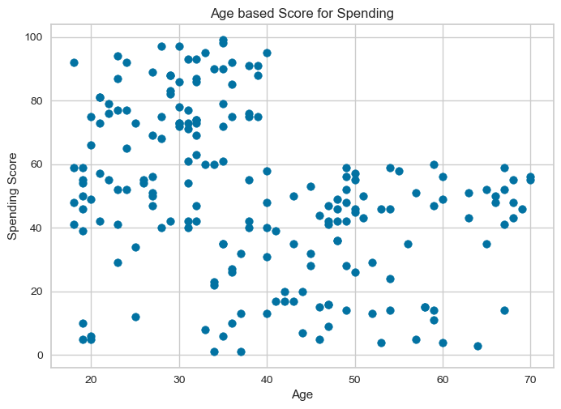

```python
plt.scatter(customersDatacopy['Age'], customersDatacopy['Spending Score'])
plt.xlabel('Age')
plt.ylabel('Spending Score')
plt.title('Age based Score for Spending')
plt.show()
```

#### *ii. Determine optimal number of clusters*

## 1. Elbow method

```python
ssd = kElbow(customersDatacopy)
ssd
```

```
[75433.10275689224,
 45700.52490298567,
 28025.84454154002,
 23640.501345274948,
 19539.11031585142,
 15427.705505966342,
 12833.120248878959,
 11262.349396926253,
 9956.884245913694]
```

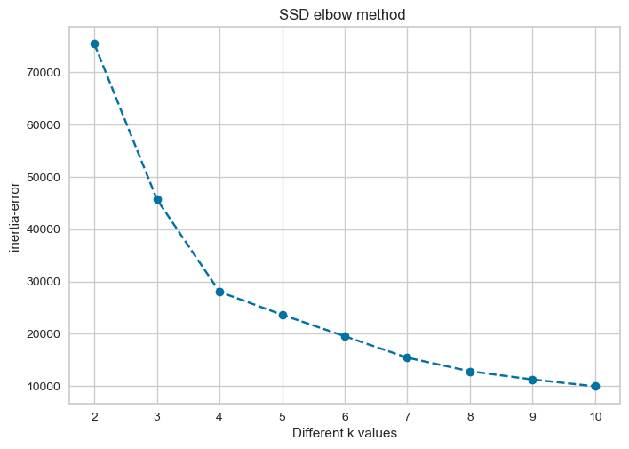

```python
VisualizingssdOfData(ssd)
```

```python
-pd.Series(ssd).diff()
```

```
0             NaN
1    29732.577854
2    17674.680361
3     4385.343196
4     4101.391029
5     4111.404810
6     2594.585257
7     1570.770852
8     1305.465151
dtype: float64
```

```python
distortion = distortionOfK(customersDatacopy)
distortion
```

```
[730.1891547477715,
 652.9052495153721,
 572.6903198352588,
 591.7478893007562,
 591.1793728697966,
 564.0253940944247,
 521.8993304241642,
 524.1171924544115,
 514.8252283999958]
```

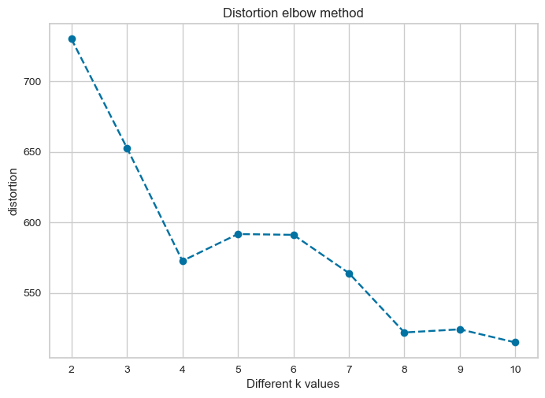

```python
VisualizingDistortionOfData(distortion)
```

### Why silhouette_score is negative?

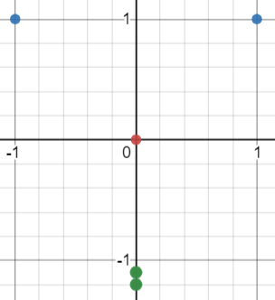

#### *iii. Apply K Means*

```python
K_means_model_ageSpending = KMeans(n_clusters=5, random_state=42)
K_means_model_ageSpending.fit(customersDatacopy)
```

```
KMeans(n_clusters=5, random_state=42)
```

```python
silhouette_score(customersDatacopy, K_means_model_ageSpending.labels_)
```

```
0.44505840166673744
```

#### *iv. Visualizing and Labeling All the Clusters*

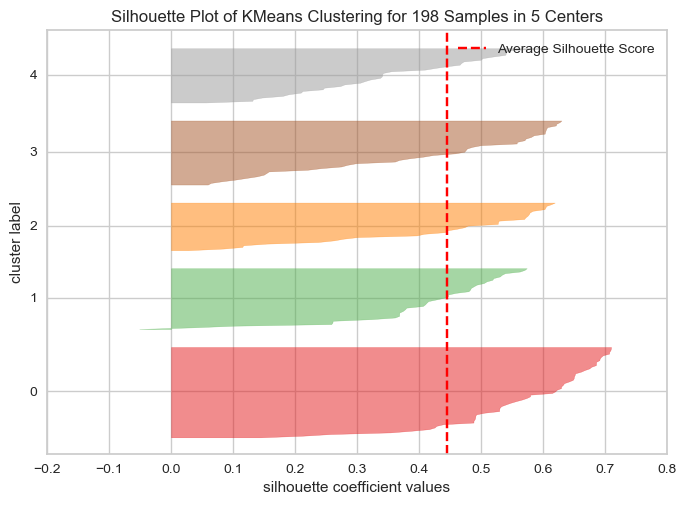

```python
visualizer = SilhouetteVisualizer(K_means_model_ageSpending)

visualizer.fit(customersDatacopy)
visualizer.poof();
```

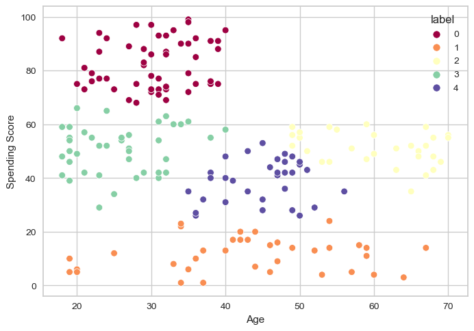

```python
ageSpendingScore = customersDatacopy.copy()
ageSpendingScore['label'] = K_means_model_ageSpending.fit_predict(customersDatacopy)
sns.scatterplot(data = ageSpendingScore,
                x = 'Age',
                y='Spending Score',
                hue='label',
                palette='Spectral')
plt.show();
```

### Clustering based on Annual Income and Spending Score

#### *i. Create a new dataset with two variables of your choice*

```python
customersDatacopy1 = customersData[['Annual Income', 'Spending Score']].copy()
```

```python
customersDatacopy1.sample(5)
```

|  | Annual Income | Spending Score |
| --- | --- | --- |
| 76 | 54 | 53 |
| 189 | 103 | 85 |
| 12 | 20 | 15 |
| 8 | 19 | 3 |
| 68 | 48 | 59 |

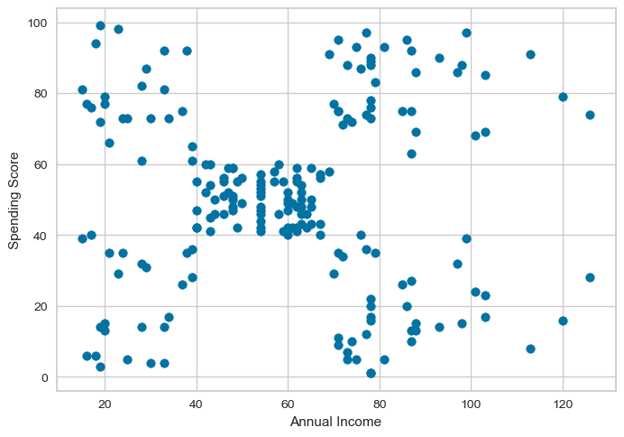

```python
plt.scatter(customersDatacopy1['Annual Income'], customersDatacopy1['Spending Score'])
plt.xlabel('Annual Income')
plt.ylabel('Spending Score')
plt.show();
```

#### *ii. Determine optimal number of clusters*

## 1. Elbow method

```python
ssd1 = kElbow(customersDatacopy1)
ssd1
```

```
[172491.3181818182,
 101166.23927650372,
 68497.65525388088,
 39345.277077327715,
 33830.090384563555,
 28373.35221337802,
 23259.080375180376,
 20090.669322989674,
 18001.523696713914]
```

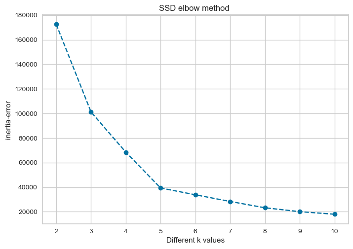

```python
VisualizingssdOfData(ssd1)
```

```python
-pd.Series(ssd1).diff()
```

```
0             NaN
1    71325.078905
2    32668.584023
3    29152.378177
4     5515.186693
5     5456.738171
6     5114.271838
7     3168.411052
8     2089.145626
dtype: float64
```

```python
distortion1 = distortionOfK(customersDatacopy1)
distortion1
```

```
[1705.454132231405,
 1239.3402592172404,
 1230.511510789197,
 1084.8990334841233,
 1077.2933312815596,
 1107.8758627800955,
 1095.2665658752037,
 1043.9536872652207,
 1030.1894440352507]
```

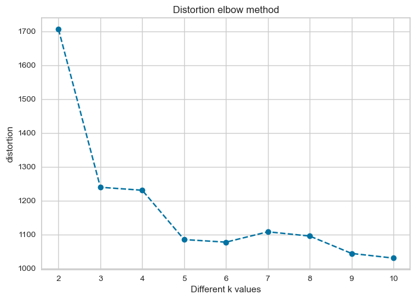

```python
VisualizingDistortionOfData(distortion1)
```

#### In both tests it was k = 5 the best value

#### *iii. Apply K Means*

```python
K_means_model_AnnualSpending = KMeans(n_clusters=5, random_state=42)
K_means_model_AnnualSpending.fit(customersDatacopy1)
```

```
KMeans(n_clusters=5, random_state=42)
```

```python
silhouette_score(customersDatacopy1, K_means_model_AnnualSpending.labels_)
```

```
0.5606825090788626
```

#### *iv. Visualizing and Labeling All the Clusters*

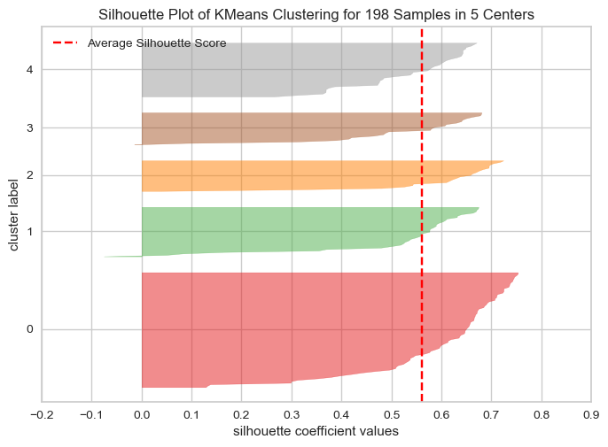

```python
visualizer = SilhouetteVisualizer(K_means_model_AnnualSpending)
visualizer.fit(customersDatacopy1)
visualizer.poof();
```

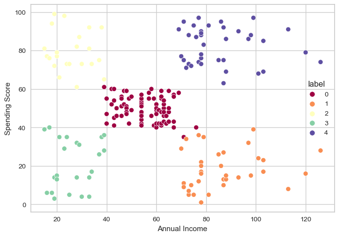

```python
AnnualSpendingScore = customersDatacopy1.copy()
AnnualSpendingScore['label'] = K_means_model_AnnualSpending.fit_predict(customersDatacopy1)
sns.scatterplot(data = AnnualSpendingScore,
                x = 'Annual Income',
                y='Spending Score',
                hue='label',
                palette='Spectral')
plt.show();
```

### Hierarchical Clustering

```python
def linkageMethods(data) :
    return [linkage(data, method='ward')
          ,linkage(data, 'complete')
          ,linkage(data, 'average')
          ,linkage(data, 'single')
         ]
```

```python
def Visualizinglinkage(hc) :
    plt.figure(figsize = (20,12))

    plt.subplot(221)
    plt.title("Ward")
    plt.xlabel("Observations")
    plt.ylabel("Distance")
    dendrogram(hc[0], leaf_font_size = 10, truncate_mode='lastp', p = 10);

    plt.subplot(222)
    plt.title("Complete")
    plt.xlabel("Observations")
    plt.ylabel("Distance")
    dendrogram(hc[1], leaf_font_size = 10, truncate_mode='lastp', p = 10);

    plt.subplot(223)
    plt.title("Average")
    plt.xlabel("Observations")
    plt.ylabel("Distance")
    dendrogram(hc[2], leaf_font_size = 10, truncate_mode='lastp', p = 10);

    plt.subplot(224)
    plt.title("Single")
    plt.xlabel("Observations")
    plt.ylabel("Distance")
    dendrogram(hc[3], leaf_font_size = 10, truncate_mode='lastp', p = 10);
```

### *i. Determine optimal number of clusters using Dendogram*

### Clustering based on Age and Spending Score- x1

```python
hc = linkageMethods(customersDatacopy)
hc
```

[output not shown]

[output cut: 733 more lines]

[output not shown]

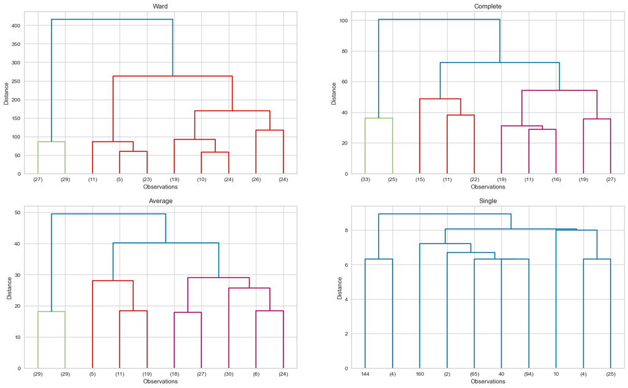

```python
Visualizinglinkage(hc)
```

with diffirent linkage method the optimal cluster number is around 4

## Clustering based on Annual Income and Spending Score- x2

```python
hc1 = linkageMethods(customersDatacopy1)
hc1
```

[output not shown]

[output cut: 733 more lines]

[output not shown]

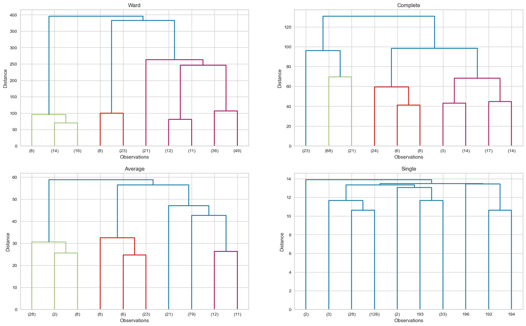

```python
Visualizinglinkage(hc1)
```

### ii. *Apply Agglomerative Clustering*

```python
def ApplyAgglomerativeClustering(data):
    scores = []
    for k in range(2, 11):
        model = AgglomerativeClustering(n_clusters = k)
        model.fit(data)
        cluster_labels = model.labels_
        silhouette_avg = silhouette_score(data, cluster_labels)
        scores.append(silhouette_avg)
    return scores
```

```python
def VisualizingAgglomerativeClustering(scores) :
    plt.plot(range(2, 11), scores, 'bo--')
    plt.xlabel('k values')
    plt.ylabel('silhouette score')
    plt.title('Silhouette Scores for Agglomerative Clustering');
```

#### Age and Spending Score- x1

```python
scores = ApplyAgglomerativeClustering(customersDatacopy)
scores
```

```
[0.4525140520182348,
 0.43934533881365695,
 0.45851897764516286,
 0.40266377756722704,
 0.411583951907362,
 0.3881760981376017,
 0.3902435246156407,
 0.3980035974612712,
 0.390593187100643]
```

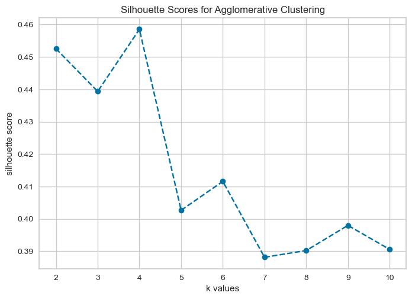

```python
VisualizingAgglomerativeClustering(scores)
```

```python
AgglomerativeClusteringCustomersDatacopy = AgglomerativeClustering(n_clusters = 4, metric = 'euclidean',linkage = 'ward')
AgglomerativeClusteringCustomersDatacopy.fit(customersDatacopy)
```

```
AgglomerativeClustering(metric='euclidean', n_clusters=4)
```

```python
aggCustomersDatacopy = customersDatacopy.copy()
aggCustomersDatacopy['label'] = AgglomerativeClusteringCustomersDatacopy.fit_predict(customersDatacopy)
aggCustomersDatacopy['label']
```

```
0      0
1      3
2      2
3      3
4      0
      ..
193    3
194    2
195    3
196    0
197    3
Name: label, Length: 198, dtype: int64
```

#### Annual Income and Spending Score- x2

```python
scores1 = ApplyAgglomerativeClustering(customersDatacopy1)
scores1
```

```
[0.38316504562235143,
 0.45841703688028984,
 0.49418859683336847,
 0.5593054601700206,
 0.44922988584727047,
 0.4427548399360259,
 0.4279025360024148,
 0.4342629725093042,
 0.43479808819584603]
```

[figure not shown]

```python
VisualizingAgglomerativeClustering(scores)
```

```python
AgglomerativeClusteringCustomersDatacopy1 = AgglomerativeClustering(n_clusters = 4, metric = 'euclidean',linkage = 'ward')
AgglomerativeClusteringCustomersDatacopy1.fit(customersDatacopy1)
```

```
AgglomerativeClustering(metric='euclidean', n_clusters=4)
```

```python
aggCustomersDatacopy1 = customersDatacopy1.copy()
aggCustomersDatacopy1['label'] = AgglomerativeClusteringCustomersDatacopy.fit_predict(customersDatacopy1)
aggCustomersDatacopy1['label']
```

```
0      0
1      3
2      0
3      3
4      0
      ..
193    1
194    2
195    1
196    2
197    1
Name: label, Length: 198, dtype: int64
```

### iii. *Visualizing and Labeling All the Clusters*

#### Age and Spending Score- x1

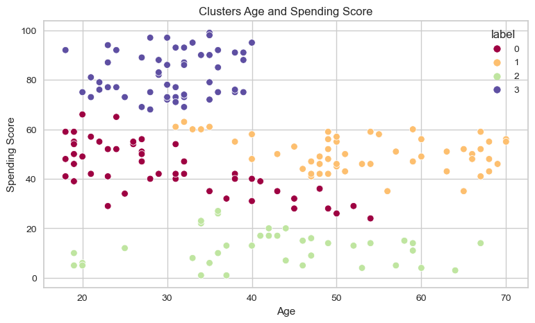

```python
plt.figure(figsize = (9,5))
sns.scatterplot(data = aggCustomersDatacopy,
                x = 'Age',
                y='Spending Score',
                hue='label',
                palette='Spectral')
plt.title('Clusters Age and Spending Score')
plt.show();
```

#### Annual Income and Spending Score- x2

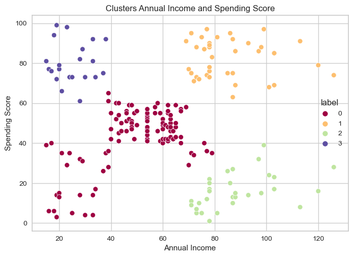

```python
sns.scatterplot(data = aggCustomersDatacopy1,
                x = 'Annual Income',
                y ='Spending Score',
                hue ='label',
                palette='Spectral')
plt.title('Clusters Annual Income and Spending Score')
plt.show();
```

#### Interpretation based on Age and Spending Score- x1

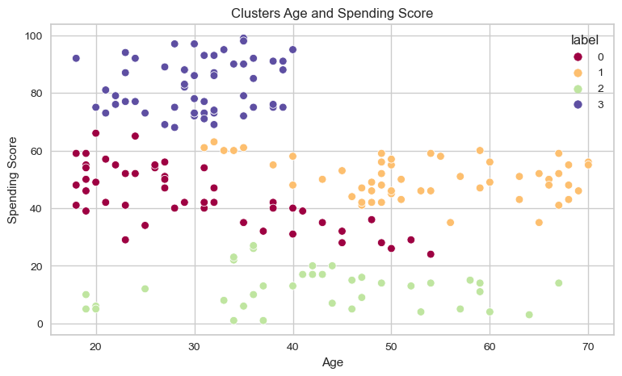

```python
plt.figure(figsize = (9,5))
sns.scatterplot(data = aggCustomersDatacopy,
                x = 'Age',
                y='Spending Score',
                hue='label',
                palette='Spectral')
plt.title('Clusters Age and Spending Score')
plt.show();
```

## Conclusion

**cluster 0** : The average age is around 40, both annula_income and spending_scores are on average. It should be researched what can be done to direct more spending.

**cluster 3**: The average age is around 25. Low annual_incomes but very high spending scores. This group does a lot of shopping, but they do not bring much profit.

**cluster 3**: The average age is around 25. Low annual_incomes but very high spending scores. This group does a lot of shopping, but they do not bring much profit.

**cluster 0** : The average age is around 40, both annula_income and spending_scores are on average. It should be researched what can be done to direct more spending.

**cluster 1**: The average age is around 30, both annula_income and spending_scores are very high. This group consists of our loyal customers. Our company derives the main profit from this group. Very special promotions can be made in order not to miss it.

**cluster 3**: The average age is around 25. Low annual_incomes but very high spending scores. This group does a lot of shopping, but they do not bring much profit.

[figure not shown]